# BMI 713 Problem Set #4 Question 2, Fall 2023

Cheryl Gu

2023-10-11

## Problem 2: Interactive clustering analysis on O2portal (24 points)

For this question, you will use RStudio through the online O2portal to conduct cluster and visualize the cleaned data.

Go to the O2portal website (https://o2portal.rc.hms.harvard.edu/pun/sys/dashboard) and launch an RStudio session. Choose the priority partition, 1 core, 5 hours of runtime, and 1 GB of memory. Make sure you load the necessary modules to run R in the “Modules to be loaded” section. Check the “Make /n/groups available” box.

Once your RStudio session launches, copy the R markdown file from /n/groups/training/bmi713/2023_problemset4_Q2.Rmd to your working directory. (You can either do this from the terminal in the RStudio session, or from a separate Terminal/GitBash session on your local computer.) Go through the rest of Problem 2 in the R Markdown file on O2portal.

##### 2.1 (1 point)

Read the `neiss_cleaned.csv` file you saved in question 1.6 to a data frame called `neiss_cleaned`.

```r
neiss_cleaned <- read.csv("~/neiss_cleaned.csv")
```

##### 2.2 (5 points)

Imagine we want to cluster the body parts in this dataset based on the age and day of the year using k-means. Generate a table where the rows are body parts and there are two numeric columns: average age and median day of the year. (Hint: lubridate has a function to generate the day of the year.)

```r
neiss_cleaned$day_of_year <- yday(as.Date(neiss_cleaned$Treatment_Date))
body_parts <- neiss_cleaned %>%
  group_by(Body_Part) %>%
  summarise(
    avg_age = mean(Age, na.rm = TRUE),
    median_day_of_year = median(day_of_year, na.rm = TRUE)) %>%
  column_to_rownames(var = "Body_Part")
```

##### 2.3 (3 points)

Make a scatter plot of the body parts, with average age on the x axis and median day of year on the y axis. Your points do not need to be labeled. Make sure that your scatter plot has informative title and axis titles and that all text is legible.

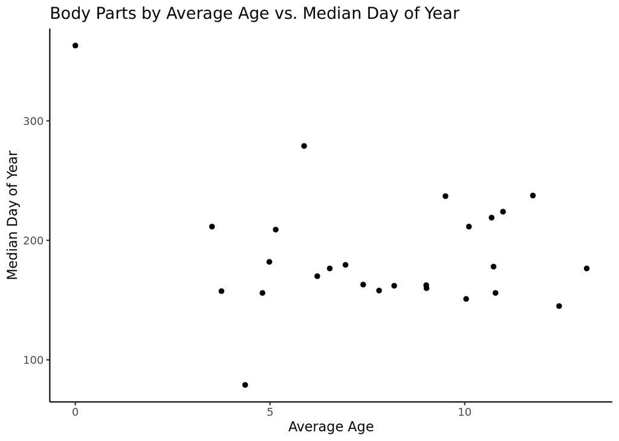

```r
body_parts %>% ggplot() +
  aes(x=avg_age, y=median_day_of_year) +
  geom_point() +
  labs(
    title = "Body Parts by Average Age vs. Median Day of Year",
    x = "Average Age",
    y = "Median Day of Year"
  ) +
  theme_classic()
```

### 2.4 (3 points)

*Scale* both the average age and the average day of year such that both have a mean of 0 and a variance of 1 and save the new data as a variable called `neiss_scaled`. Save `neiss_scaled` as a CSV file in your working directory for future use.

```r
neiss_scaled <- body_parts %>%
  mutate(
    scaled_avg_age = scale(avg_age),
    scaled_median_day_of_year = scale(median_day_of_year)
  )
write.csv(neiss_scaled, "neiss_scaled.csv", row.names = FALSE)
```

### 2.5 (9 points)

Run k-means clustering with k=3 and default centroid initialization on the raw data, and separately on the scaled data. Make side-by-side scatter plots of the body parts (as in 2.3) where the points are colored by their cluster assignment: the left-side scatter plot should be colored by clusters from the raw data, the right-side scatter plot should be colored by clusters from the scaled data. (There are multiple ways you can make these side-by-side plots — we do not have a preference, as long as the plots are in the same image.) If you want to use a function that is not in the packages you installed in 1.5, you can install the necessary package(s) now.

*Reminder: at the top of any `{r}` chunk that calls the k-means clustering algorithm, set your seed equal to 713.*

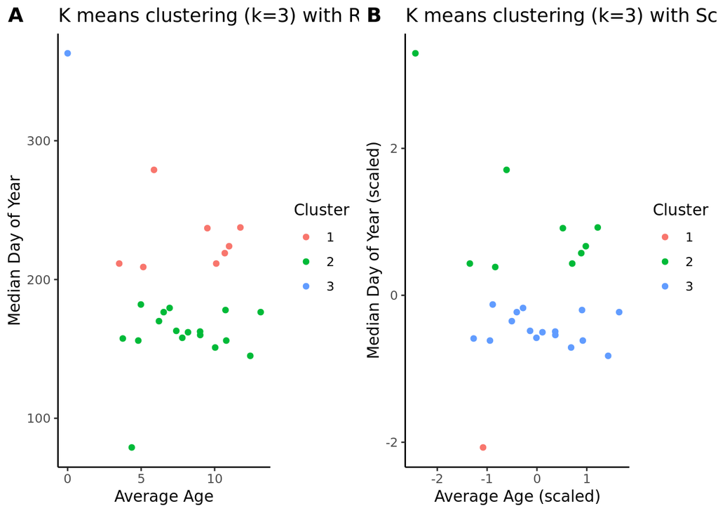

```r
set.seed(713)
k = 3
kclusters_raw <- kmeans(body_parts, k)
kclusters_scaled = kmeans(neiss_scaled, k)
plot_raw <- ggplot(body_parts, aes(x=avg_age, y=median_day_of_year, color=as.factor(kclusters_raw$cluster))) +
  geom_point() +
  labs(
    title = "K means clustering (k=3) with Raw Data",
    x = "Average Age",
    y = "Median Day of Year"
  ) +
  scale_color_discrete(name="Cluster") +
  theme_classic()

# Scatter plot for scaled data
plot_scaled <- ggplot(neiss_scaled, aes(x=scaled_avg_age, y=scaled_median_day_of_year, color=as.factor(kclusters_scaled$cluster))) +
  geom_point() +
  labs(
    title = "K means clustering (k=3) with Scaled Data",
    x = "Average Age (scaled)",
    y = "Median Day of Year (scaled)"
  ) +
  scale_color_discrete(name="Cluster") +
  theme_classic()

# Combine the two plots side by side
plot_grid(plot_raw, plot_scaled, labels = c('A', 'B'))
```

### 2.6 (3 points)

Describe how the clustering results differ when using scaled and unscaled data. Provide an explanation for this difference.

```
The main difference is the cluster assignment in regard to the two extreme data values. One possible reason is dut to the default centroids may be pulled towards outliers/extreme values, and results into a larger clusters that include the outliers.
```

Once you complete Problem 2, **knit your Rmd file to an HTML on O2 and then copy the Rmd and HTML files to your Problem Set #4 repository on your local computer**. You will include these in your submission. For file transfer between O2 and local machine, refer to the guidance in the `BMI713_copyFiles.pdf` on Canvas (https://canvas.harvard.edu/courses/125814/files/folder/Week%205?preview=18410800) or the O2 Wiki about file transfer (https://harvardmed.atlassian.net/wiki/spaces/O2/pages/1588662157/File+Transfer).